# Goldbaum Research part

```python
import numpy as np
import pandas as pd
import matplotlib.pyplot as plt
from pandas_datareader import data
import datetime
from mpl_toolkits import mplot3d
from matplotlib.colors import LogNorm
```

**Step 1 - Get data**

```python
# Obtain daily dividend data from yahoo finance

tickers = ['SPX5.L', 'SC0E.DE', 'SGLD.L'] # 'ILTB.A'
start_date = '2013-10-31'
end_date = '2018-10-30'
df = data.DataReader(tickers, 'yahoo', start_date, end_date)
```

```python
df.head()
```

| Attributes Symbols Date | High SC0E.DE | High SGLD.L | High SPX5.L | Low SC0E.DE | Low SGLD.L | Low SPX5.L | Open SC0E.DE | Open SGLD.L | Open SPX5.L | Close SC0E.DE | Close SGLD.L | Close SPX5.L | Volume SC0E.DE | Volume SGLD.L | Volume SPX5.L | Adj Close SC0E.DE | Adj Close SGLD.L | Adj Close SPX5.L |
| --- | --- | --- | --- | --- | --- | --- | --- | --- | --- | --- | --- | --- | --- | --- | --- | --- | --- | --- |
| 2013-10-31 | 160.419998 | 82.203598 | 176.490005 | 160.419998 | 81.732002 | 176.110001 | 160.419998 | 82.203598 | 176.330002 | 160.419998 | 81.309998 | 176.544998 | 0.0 | 85.0 | 5470.0 | 160.419998 | 81.309998 | 162.337784 |
| 2013-11-01 | NaN | 81.339996 | 176.800003 | NaN | 81.306297 | 175.990005 | NaN | 81.306297 | 175.990005 | NaN | 81.445000 | 175.750000 | NaN | 11.0 | 17126.0 | NaN | 81.445000 | 161.606766 |
| 2013-11-04 | NaN | 81.626701 | 176.880005 | NaN | 81.626701 | 176.520004 | NaN | 81.626701 | 176.610001 | NaN | 81.485001 | 176.520004 | NaN | 20.0 | 683.0 | NaN | 81.485001 | 162.314789 |
| 2013-11-05 | NaN | 80.760002 | 176.649994 | NaN | 80.654503 | 176.429993 | NaN | 80.760002 | 176.520004 | NaN | 80.635002 | 176.485001 | NaN | 2373.0 | 6781.0 | NaN | 80.635002 | 162.282608 |
| 2013-11-06 | NaN | 80.949997 | 177.619995 | NaN | 80.949997 | 177.619995 | NaN | 80.949997 | 177.619995 | NaN | 80.855003 | 177.139999 | NaN | 2003.0 | 1004.0 | NaN | 80.855003 | 162.884872 |

```python
# Fill any NaN values with most recent non-null value

df['Close'] = df['Close'].fillna(method = 'ffill')
df['Adj Close'] = df['Adj Close'].fillna(method = 'ffill')
```

**Step 2 - CAGR, volatility, volume rolling average**

```python
# Annual compounded growth rate
#There are 5 years, so dividing by 5
# CAGR   =   ( EV / BV)**(1 / n) - 1; EV-ending, BV-beginning value, n-no. of periods

def CAGR(df, ticker):
    return np.power(df[df['Adj Close'][ticker].isna()==False]['Adj Close'][ticker][-1]/df['Open'][ticker][0], 1/5) - 1
```

```python
CAGR_results = []
for ticker in tickers:
    CAGR_results.append(CAGR(df, ticker))
```

```python
# CAGR values for the three products

CAGR_results
```

```
[0.03856360851280538, 0.05000914288569347, 0.016948727347266823]
```

```python
# Annual volatilities for each of the 3 products
# Annual volatility = sum(x-mean)**2/n; n- no.of days in year

def get_annual_volatilities(df, ticker):
    return [((df['Adj Close'][ticker][i : i+252] -  df['Adj Close'][ticker][i : i+252].mean())**2).mean() for i in range(0, len(df), 252)]
```

```python
# Annual volatilities for the 3 products over 2013-2018

annual_volatilities = []

for ticker in tickers:
    annual_volatilities.append(get_annual_volatilities(df, ticker))
    print(ticker, ':', get_annual_volatilities(df, ticker))
```

```
SPX5.L : [57.04040283298647, 24.65864197175812, 89.44924528378777, 122.9838946824219, 701.6899578211685]
SC0E.DE : [36.86046630224032, 157.49783836780483, 48.465638766007395, 71.74785885448189, 27.374699988974246]
SGLD.L : [3.958152822671171, 18.44441798409826, 117.7379491058155, 6.201465314636737, 255.985885066476]
```

```python
# Volume yearly rolling average
# 252 trading days per year

volume_rolling = df['Volume'].rolling(252, min_periods = 1).mean()
volume_rolling. tail()
```

| Symbols Date | SC0E.DE | SGLD.L | SPX5.L |
| --- | --- | --- | --- |
| 2018-10-25 | 1742.827869 | 25621.200000 | 12824.081545 |
| 2018-10-26 | 1720.434426 | 25816.385965 | 12806.721030 |
| 2018-10-29 | 1696.721311 | 26006.858407 | 11713.214592 |
| 2018-10-30 | 1708.254098 | 26197.178571 | 11639.811159 |
| 2018-10-31 | 1664.168033 | 26324.054054 | 11648.862661 |

**Step 3 - Moving Average Trading Strategy**

```python
def trading_strategy(df, short_period, long_period):

    # Get short and long-rolling moving averages and create trading dataframe using their difference
    short_rolling = df['Adj Close'].rolling(window = short_period).mean()
    long_rolling = df['Adj Close'].rolling(window = long_period).mean()

    trading = pd.DataFrame(np.where(short_rolling > long_rolling, 1.0, 0.0))[long_period-1:]
    trading.index = short_rolling[long_period-1:].index

    # Shift trading signals by 1 day, since the difference is calculated on the closing prices
    # of the current day and the buy/sell will only be applied on the following day

    trading = trading.shift(1)
    trading = trading[1:]
    trading.columns = short_rolling.columns

    # Divide the trading values by 3, since the shares are equally split between the 3 products (equal weights).
    # Multiply the trading values by 100, since we are buying/selling 100 shares at each transaction.
    trading = trading.apply(np.sign) * 100/3

    # Obtain the positions where the signal changes (buy/sell)
    change_positions = trading.diff()
    change_positions.iloc[0] = (trading.iloc[0]>0).astype(float)*100/3

    return trading, change_positions
```

Function to create a backtest for the current dataset. The holdings are the total value of the owned shares at a specific point in time. If trading indicates that the last transaction was a buy, then the holdings are calculated as the number of shares owned multiplied by their current price. If the last transaction was a sell, the holdings will be 0.

The cash is calculated by using the initial capital of $ 100,000 and adding/substracting the amount every time shares are sold/bought.

The total at any point in time is the sum of holdings and cash owned. The metric we use to analyse the trading strategy is the annualized Sharpe ratio. This calculates the yearly differences in total and also takes into account the volatility of the profit.

```python
def backtest(df, trading, change_positions, long_period):

    holdings = trading * (df['Adj Close'][long_period:])

    initial_capital = float(100000)
    cash = initial_capital - (change_positions * df['Adj Close'][long_period:]).cumsum()

    total = cash + holdings

    returns = total.pct_change()
    ann_sharpe_ratio = np.sqrt(252) * (returns.mean()/returns.std())

    return ann_sharpe_ratio, total
```

Function to optimize the parameters of the trading strategy (period of short rolling average, period of long rolling average). For the given combinations of short and long periods, a new trading strategy is created and backtested. For each combination of parameters, the annualized Sharpe ratio is stored.

```python
def optimize(df, short_periods, long_periods):
    ann_sharpe_ratios = []
    param_tuples = []

    for short_period in short_periods:
        for long_period in long_periods:

            # Create strategy using current parameters
            trading, change_positions = trading_strategy(df, short_period, long_period)

            ann_sharpe_ratio, total = backtest(df, trading, change_positions, long_period)
            ann_sharpe_ratios.append(ann_sharpe_ratio)
            param_tuples.append((short_period, long_period))

    return ann_sharpe_ratios, param_tuples
```

The following is a step-by-step illustration of the entire process. The initial parameter values are 60 and 140. At the end, the optimization will be run and better values will be obtained.

```python
# Calculate the short-rolling and long-rolling mean of adjusted closing values

short_rolling = df['Adj Close'].rolling(window = 60).mean()
long_rolling = df['Adj Close'].rolling(window = 140).mean()
long_rolling.tail()
```

| Symbols Date | SC0E.DE | SGLD.L | SPX5.L |
| --- | --- | --- | --- |
| 2018-10-25 | 214.705892 | 108.468396 | 234.570469 |
| 2018-10-26 | 214.643392 | 108.178538 | 234.165675 |
| 2018-10-29 | 214.580892 | 107.888681 | 233.771808 |
| 2018-10-30 | 214.524464 | 107.598824 | 233.373274 |
| 2018-10-31 | 214.478035 | 107.308967 | 232.977353 |

```
Text(0,0.5,'Price')
```

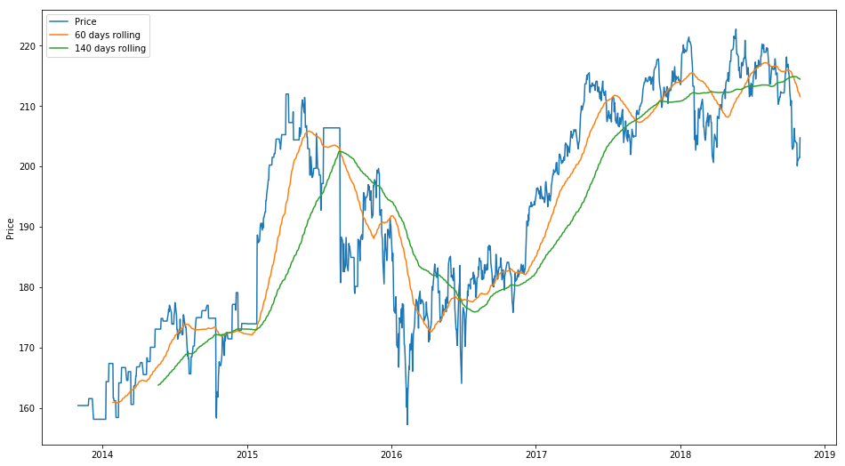

```python
# Plot graph of price, shot-running and long-running mean prices for the SC0E.DE product
# When the 60 days rolling overtakes the 140 days rolling, the investor will go long. Otherwise, the investor goes short.

fig, ax = plt.subplots(figsize = (16,9))

ax.plot(df['Adj Close']['SC0E.DE'], label = 'Price')
ax.plot(short_rolling['SC0E.DE'], label = '60 days rolling')
ax.plot(long_rolling['SC0E.DE'], label = '140 days rolling')

ax.legend(loc = 'best')
ax.set_ylabel('Price')
```

```python
# Take the sign of the difference to check if the short-rolling mean is greater than the long-rolling mean
# Multiply by the weight, which is 1/3 since the trades are split equally between the 3 products
# Multiply by 100 for each asset, since we are buying/selling 100 shares of each

trading = pd.DataFrame(np.where(short_rolling > long_rolling, 1.0, 0.0))[140:]
trading.index = short_rolling[140:].index

# Shift trading signals by 1 day, since the difference is calculated on the closing prices of the current day and the buy/sell will only be applied on the following day

trading = trading.shift(1)
trading = trading[1:]
trading = trading.apply(np.sign) * 100/3
trading.columns = short_rolling.columns
trading.head()
```

| Symbols Date | SC0E.DE | SGLD.L | SPX5.L |
| --- | --- | --- | --- |
| 2014-05-27 | 33.333333 | 33.333333 | 33.333333 |
| 2014-05-28 | 33.333333 | 33.333333 | 33.333333 |
| 2014-05-29 | 33.333333 | 33.333333 | 33.333333 |
| 2014-05-30 | 33.333333 | 33.333333 | 33.333333 |
| 2014-06-02 | 33.333333 | 33.333333 | 33.333333 |

```python
change_positions = trading.diff()
change_positions.iloc[0] = (trading.iloc[0]>0).astype(float)*100/3
change_positions.head()
```

| Symbols Date | SC0E.DE | SGLD.L | SPX5.L |
| --- | --- | --- | --- |
| 2014-05-27 | 33.333333 | 33.333333 | 33.333333 |
| 2014-05-28 | 0.000000 | 0.000000 | 0.000000 |
| 2014-05-29 | 0.000000 | 0.000000 | 0.000000 |
| 2014-05-30 | 0.000000 | 0.000000 | 0.000000 |
| 2014-06-02 | 0.000000 | 0.000000 | 0.000000 |

Backtest for params = (60,140)

```python
# Get holdings by multiplying trading signals with daily prices

holdings = trading * (df['Adj Close'][140:])
```

```python
# Get cash - represented as initial capital plus sold assets minus bought assets

initial_capital = float(100000)

cash = initial_capital - (change_positions * df['Adj Close'][140:]).cumsum()
```

```
Text(0,0.5,'Total amount owned ($)')
```

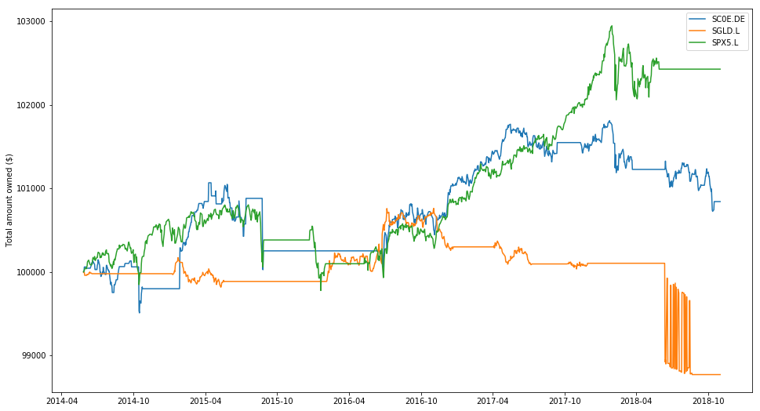

```python
# Get the total amount owned

total = cash + holdings
fig, ax = plt.subplots(figsize = (16,9))
products = ['SC0E.DE', 'SGLD.L', 'SPX5.L']

for product in products:
    ax.plot(total[product], label = product)

ax.legend(loc = 'best')
ax.set_ylabel('Total amount owned ($)')
```

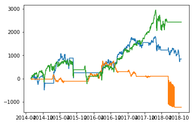

```python
profit = total - initial_capital
plt.plot(profit)
```

```python
# Evaluate the strategy using annualized Sharpe ratio calculation

returns = total.pct_change()
ann_sharpe_ratio = np.sqrt(252) * (returns.mean()/returns.std())
ann_sharpe_ratio
```

```
Symbols
SC0E.DE    0.240173
SGLD.L    -0.119172
SPX5.L     0.724187
dtype: float64
```

```python
# Optimize the strategy using a brute force approach

short_periods = np.array([10,20,30,40,50,60])
long_periods = np.array([70,80,90,100,110,120,130,140])

ann_sharpe_ratios, param_tuples = optimize(df, short_periods, long_periods)
sharpe_df = pd.DataFrame(data = ann_sharpe_ratios, index = param_tuples)
sharpe_df.index.name = 'Parameters'
sharpe_df.tail()
```

| Symbols Parameters | SC0E.DE | SGLD.L | SPX5.L |
| --- | --- | --- | --- |
| (60, 100) | 0.227810 | -0.052732 | 0.441514 |
| (60, 110) | 0.333460 | -0.149037 | 0.600138 |
| (60, 120) | 0.393237 | -0.047837 | 0.546574 |
| (60, 130) | 0.377351 | -0.139924 | 0.686007 |
| (60, 140) | 0.240064 | -0.123536 | 0.730870 |

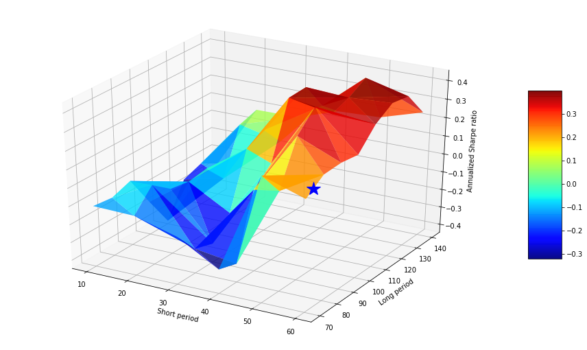

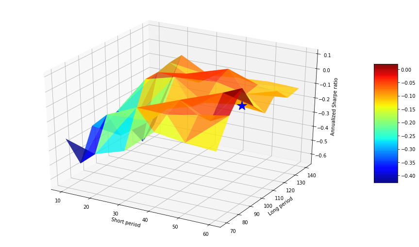

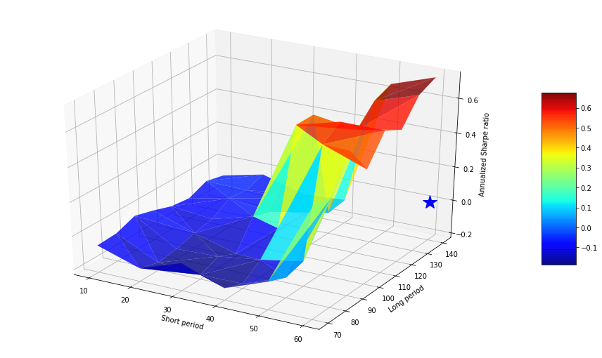

```python
# 3D plot of annualized sharpe ratios wrt parameters (for each product, plot the Sharpe ratio for each combination of the 2 params)
# For each product, the star is placed right beneath the maximum ratio value, to indicate the optimal parameters.

short, long = zip(*param_tuples)

X, Y = short, long

for product in sharpe_df.columns:
    fig = plt.figure(figsize=(16,9))
    ax = fig.gca(projection='3d')

    Z = sharpe_df[product]

    surf = ax.plot_trisurf(X, Y, Z,
                edgecolor='none', alpha=.8, cmap=plt.cm.jet)
    ax.set_xlabel('Short period')
    ax.set_ylabel('Long period')
    ax.set_zlabel('Annualized Sharpe ratio')

    xmax, ymax = sharpe_df[product].idxmax()
    ax.plot(np.array([xmax]), np.array([ymax]), 'b*', markersize = 20)

    fig.colorbar(surf, shrink=0.5, aspect=5)
```

```python
# Win-loss ratio of the trading basket
# no. of profitable transactions/ no. of unsuccessful transactions

def get_win_loss_ratios(products):
    ratios = []
    for product in products:
        ids = change_positions[change_positions[product]!=0].index
        ratio = (total.loc[ids,product].diff().apply(np.sign)>0).sum() / (total.loc[ids,product].diff().apply(np.sign)<0).sum()
        ratios.append((product,ratio))
    return ratios
```

```python
# Win-loss ratios of the 3 products

products = ['SC0E.DE', 'SGLD.L', 'SPX5.L']
get_win_loss_ratios(products)
```

```
[('SC0E.DE', 1.0), ('SGLD.L', 0.4), ('SPX5.L', 3.0)]
```

```python
# Maximum drawdown
# Defined as biggest peak-to-valley (largest decrease in profit)
# Represented as percentage of total amount right before the start of the decrease

def get_maximum_drawdown(products):
    max_dds = []

    for product in products:
        i = np.argmax(np.maximum.accumulate(total[product][1:]) - total[product][1:]) # end of the period
        j = np.argmax(total[product][:i]) # start of period
        max_drawdown = (total[product][j] - total[product][i])/total[product][j]
        max_dds.append((product,max_drawdown))

    return max_dds
```

```python
# Maximum drawdowns for the 3 products

products = ['SC0E.DE', 'SGLD.L', 'SPX5.L']
get_maximum_drawdown(products)
```

```
[('SC0E.DE', 0.010673264121149226),
 ('SGLD.L', 0.01975135941977849),
 ('SPX5.L', 0.010177663330787432)]
```

```python
# Volatility
# Represents the oscillation in total amount owned ($)

def get_volatilities(products):
    volatilities = []
    for product in products:
        volatilities.append((product,total[product].std()))
    return volatilities
```

```python
# Volatility for the 3 products

get_volatilities(products)
```

```
[('SC0E.DE', 578.457060424479),
 ('SGLD.L', 402.748918482527),
 ('SPX5.L', 864.8240832739467)]
```

**Step 4 - Sensitivity of strategy on new markets**

```python
# Obtain  S&P 500 INDEX(Frankfurt), MSCI EUROPE INDEX(Frankfurt) and GOLD(Milan) indices from yahoo finance

tickers = ['SPY5.F', 'SC0E.F', 'SGLD.MI']
start_date = '2016-10-31'
end_date = '2018-10-30'
df2 = data.DataReader(tickers, 'yahoo', start_date, end_date)
```

```python
# Apply the trading strategy to this new basket and optimize parameters
# Obtain a dataframe of all possible parameter combinations and their Sharpe ratios

short_periods = np.array([5,10,20,30,40,50,60])
long_periods = np.array([70,80,90,100,110,120,130,140])

ann_sharpe_ratios, param_tuples = optimize(df2, short_periods, long_periods)

sharpe_df = pd.DataFrame(data = ann_sharpe_ratios, index = param_tuples)
sharpe_df.index.name = 'Parameters'
```

```python
# Obtain average Sharpe ratios for each possible value of the short-rolling period

xmeans = []

for i in range(0, len(sharpe_df), len(long_periods)):
    xmeans.append(sharpe_df[i:i+8].mean())

xmeans = pd.DataFrame(xmeans, columns = sharpe_df.columns, index = short_periods)

xmeans
```

| Symbols | SC0E.F | SGLD.MI | SPY5.F |
| --- | --- | --- | --- |
| 5 | 0.633979 | -0.625793 | -0.170806 |
| 10 | 0.659359 | -0.656421 | 0.134641 |
| 20 | 0.547147 | -0.702035 | 0.027727 |
| 30 | 0.533450 | -0.634853 | 0.116825 |
| 40 | 0.545864 | -1.020523 | 0.161248 |
| 50 | 0.629259 | -1.079498 | -0.045190 |
| 60 | 0.560707 | -1.169549 | 0.101558 |

```python
# Obtain average Sharpe ratios for each possible value of the long-rolling period

ymeans = []

for i in range(len(long_periods)):
    sum = 0
    for j in range(0, len(sharpe_df), len(long_periods)):
        sum=sum + sharpe_df.iloc[i+j]
    ymeans.append(sum/len(short_periods))

ymeans = pd.DataFrame(ymeans, columns = sharpe_df.columns, index = long_periods)

ymeans
```

| Symbols | SC0E.F | SGLD.MI | SPY5.F |
| --- | --- | --- | --- |
| 70 | 1.003334 | -0.837998 | 0.012643 |
| 80 | 0.873148 | -0.880913 | -0.485256 |
| 90 | 0.792553 | -0.537550 | -0.541281 |
| 100 | 0.781751 | -0.758938 | 0.117415 |
| 110 | 0.294549 | -1.018827 | -0.099781 |
| 120 | 0.696151 | -1.326512 | 0.118240 |
| 130 | 0.855137 | -0.624533 | 0.808797 |
| 140 | -0.599748 | -0.744638 | 0.441797 |

```
Text(0.5,0,'Short period')
```

[figure not shown]

```python
# Plot the Sharpe ratios against the short periods (sensitivity of trading strategy with respect to the value of short period)

fig, ax = plt.subplots(figsize = (16,9))

for product in tickers:
    ax.plot(short_periods,xmeans, label = product)

ax.legend(loc = 'best')

ax.set_ylabel('Average Sharpe ratio')
ax.set_xlabel('Short period')
```

```
Text(0.5,0,'Short period')
```

[figure not shown]

```python
# Plot the Sharpe ratios against the long periods (sensitivity of trading strategy with respect to the value of long period)

fig, ax = plt.subplots(figsize = (16,9))

for product in sharpe_df.columns:
    ax.plot(long_periods,ymeans, label = product)

ax.legend(loc = 'best')

ax.set_ylabel('Average Sharpe ratio')
ax.set_xlabel('Short period')
```

```python
# From the optimization performed previously, get the best combination of the parameters for each of the three products

optimal_params = []

for product in sharpe_df.columns:
    short, long = sharpe_df[product].idxmax()
    optimal_params.append((product,(short,long)))

optimal_params
```

```
[('SC0E.F', (10, 70)), ('SGLD.MI', (10, 130)), ('SPY5.F', (10, 140))]
```

**Step 6 - Sensitivity to macro variables**

Inflation

```python
# Get inflation rates in Germany between 10-2017 and 10-2018

inflation = pd.read_csv('inflation.csv')
```

```python
inflation.head()
```

|  | LOCATION | INDICATOR | SUBJECT | MEASURE | FREQUENCY | TIME | Value | Flag Codes |
| --- | --- | --- | --- | --- | --- | --- | --- | --- |
| 0 | AUT | CPI | TOT | AGRWTH | M | 2011-01 | 2.502317 | NaN |
| 1 | AUT | CPI | TOT | AGRWTH | M | 2011-02 | 3.021771 | NaN |
| 2 | AUT | CPI | TOT | AGRWTH | M | 2011-03 | 3.092950 | NaN |
| 3 | AUT | CPI | TOT | AGRWTH | M | 2011-04 | 3.310327 | NaN |
| 4 | AUT | CPI | TOT | AGRWTH | M | 2011-05 | 3.315974 | NaN |

```python
inflation = inflation[inflation['LOCATION']=='DEU'] # Get inflation only for the country specified
inflation = inflation.loc[736:748] # Get inflation only for the dates specified
inflation = inflation['Value'] # Only get inflation values and drop the other columns
```

```python
# Use the optimal parameters for the SPY5.F product (calculated above) to create a new backtest and obtain the profit amount

trading, change_positions = trading_strategy(df2, 10, 140)
ann_sharpe_ratio, total = backtest(df2, trading, change_positions, 140)

initial_cash = 100000
profit = total - initial_cash
```

```
Text(0.5,1,'Profit versus monthly inflation between 10-2017 and 10-2018')
```

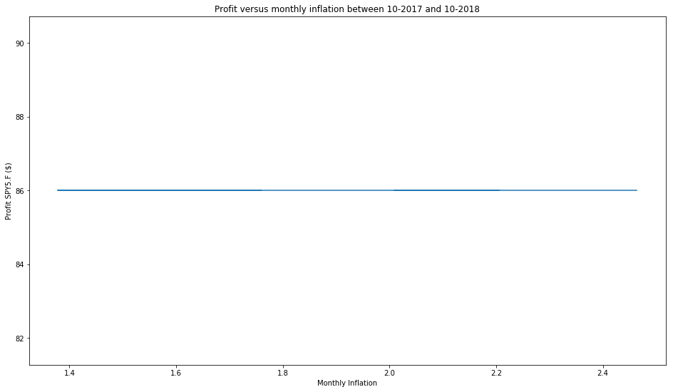

```python
# Plot the profit of the SPY5.F product against the inflation in Germany between 10-2017 and 10-2018

fig, ax = plt.subplots(figsize=(16,9))

ax.plot(inflation, profit['SPY5.F'].resample('M').mean()['2017-10-31':])

ax.set_xlabel('Monthly Inflation')
ax.set_ylabel('Profit SPY5.F ($)')
ax.set_title('Profit versus monthly inflation between 10-2017 and 10-2018')
```

GDP

```python
# Get the GDP of Germany between 04-2017 and 06-2018 (averaged over 3 months)

gdp = pd.read_csv('GDP.csv')
```

```python
gdp.head()
```

|  | LOCATION | INDICATOR | SUBJECT | MEASURE | FREQUENCY | TIME | Value | Flag Codes |
| --- | --- | --- | --- | --- | --- | --- | --- | --- |
| 0 | KOR | QGDP | TOT | PC_CHGPP | Q | 2010-Q1 | 2.209127 | NaN |
| 1 | KOR | QGDP | TOT | PC_CHGPP | Q | 2010-Q2 | 1.736918 | NaN |
| 2 | KOR | QGDP | TOT | PC_CHGPP | Q | 2010-Q3 | 0.989358 | NaN |
| 3 | KOR | QGDP | TOT | PC_CHGPP | Q | 2010-Q4 | 1.014242 | NaN |
| 4 | KOR | QGDP | TOT | PC_CHGPP | Q | 2011-Q1 | 0.972161 | NaN |

```python
gdp = gdp[gdp['LOCATION']=='DEU'] # # Get GDP only for the country specified
gdp = gdp.loc[987:] # Get GDP only for the dates specified
gdp = gdp['Value'] # Only get the GDP value and drop the other columns
```

```
Text(0.5,1,'Profit versus quarterly GDP between 04-2017 and 06-2018')
```

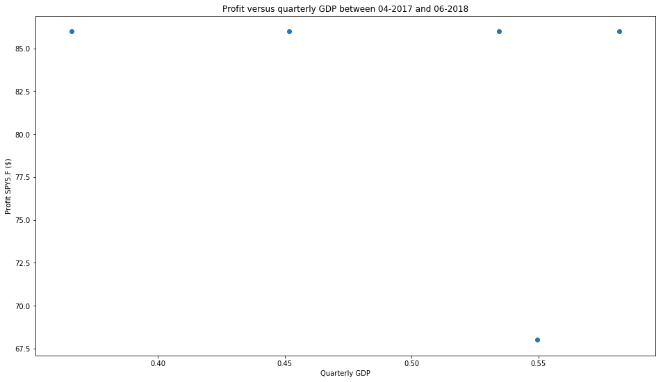

```python
# Plot the profit of the SPY5.F product against the GDP of Germany between 04-2017 and 06-2018 (averaged over 3 months)

fig, ax = plt.subplots(figsize=(16,9))

ax.scatter(gdp, profit['SPY5.F'].resample('3M').mean()['2017-04-01':][:5])

ax.set_xlabel('Quarterly GDP')
ax.set_ylabel('Profit SPY5.F ($)')
ax.set_title('Profit versus quarterly GDP between 04-2017 and 06-2018')
```

```python
# Get values of trade between 2000 and 2011 in Germany
# Not comparable with index data, since records are from 2010 to 2018

trade = pd.read_csv('trade.csv')
trade[8:14]
```

|  | #NAME? | Sorry, the query is too large to fit into the Excel cell. You will not be able to update your table with the .Stat Populator. | Unnamed: 2 | Unnamed: 3 | Unnamed: 4 | Unnamed: 5 | Unnamed: 6 | Unnamed: 7 | Unnamed: 8 | Unnamed: 9 | Unnamed: 10 | Unnamed: 11 | Unnamed: 12 | Unnamed: 13 |
| --- | --- | --- | --- | --- | --- | --- | --- | --- | --- | --- | --- | --- | --- | --- |
| 8 | AUT: Austria | NaN | 68,575.6 | 72,466.1 | 76,781.5 | 90,205.4 | 103,536.9 | 108,761.4 | 119,110.8 | 137,980.9 | 150,204.6 | 121,116.8 | 125,237.4 | 142,520.8 |
| 9 | BEL: Belgium | NaN | 105,446.9 | 105,455.3 | 109,297.8 | 129,236.2 | 152,587.2 | 154,583.6 | 168,905.8 | 189,203.0 | 222,718.0 | 174,799.0 | 171,921.5 | 200,079.9 |
| 10 | CAN: Canada | NaN | 284,200.6 | 265,826.1 | 259,491.1 | 284,133.0 | 331,370.8 | 371,072.3 | 395,887.6 | 416,378.9 | 433,833.6 | 317,423.8 | 388,462.2 | 447,352.0 |
| 11 | CHL: Chile | NaN | 14,176.0 | 13,814.0 | 13,995.6 | 15,436.5 | 22,647.5 | 28,480.2 | 39,339.9 | 42,669.4 | 38,324.0 | 29,460.3 | 36,498.6 | 43,807.9 |
| 12 | CZE: Czech Republic | NaN | 31,528.0 | 35,341.2 | 39,352.2 | 49,225.1 | 61,294.7 | 71,274.9 | 84,146.3 | 102,977.4 | 120,278.1 | 96,075.2 | 108,712.6 | 125,576.6 |
| 13 | DNK: Denmark | NaN | 51,514.2 | 51,916.3 | 53,727.4 | 64,194.9 | 73,783.3 | 83,818.2 | 89,876.5 | 103,436.1 | 120,657.5 | 95,651.2 | 97,176.5 | 109,030.8 |

Interest rate

```python
# Get monthly interest rates for Germany between 10-2017 and 10-2018

interest_rate = pd.read_csv('interest rate.csv')
```

```python
interest_rate.head()
```

|  | LOCATION | INDICATOR | SUBJECT | MEASURE | FREQUENCY | TIME | Value | Flag Codes |
| --- | --- | --- | --- | --- | --- | --- | --- | --- |
| 0 | DEU | STINT | TOT | PC_PA | M | 2011-01 | 1.0172 | NaN |
| 1 | DEU | STINT | TOT | PC_PA | M | 2011-02 | 1.0867 | NaN |
| 2 | DEU | STINT | TOT | PC_PA | M | 2011-03 | 1.1755 | NaN |
| 3 | DEU | STINT | TOT | PC_PA | M | 2011-04 | 1.3212 | NaN |
| 4 | DEU | STINT | TOT | PC_PA | M | 2011-05 | 1.4251 | NaN |

```python
interest_rate = interest_rate[175:] # Get interest rate only for the specified dates
interest_rate = interest_rate['Value'] # Only get the interest rate values and drop the other columns
```

```python
profit=profit.resample('M').mean()['2017-10-31':]['SPY5.F']
```

```
Text(0.5,1,'Profit versus monthly interest rate between 10-2017 and 10-2018')
```

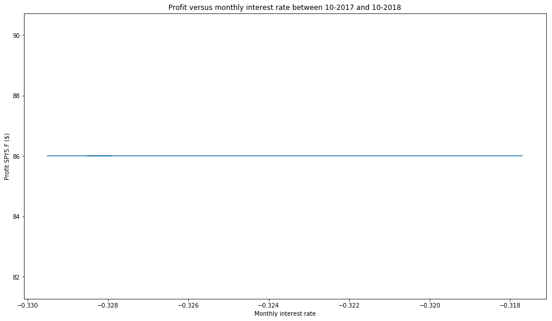

```python
# Plot the profit of SPY5.F against interest rate in Germany between 10-2017 and 10-2018

fig, ax = plt.subplots(figsize=(16,9))

ax.plot(interest_rate, profit)

ax.set_xlabel('Monthly interest rate')
ax.set_ylabel('Profit SPY5.F ($)')
ax.set_title('Profit versus monthly interest rate between 10-2017 and 10-2018')
```

The end:)